# Cumulative analysis

Zsu-Zsu Chen, Bina Choi, George Goshua, Aravind Menon

12/12/2021

Suppress messages and warnings for this markdown

```r
knitr::opts_chunk$set(message = FALSE, warning = FALSE)
```

## Overview and Motivation

Increases in real estate prices were seen across the country over the course of the COVID-19 pandemic, with the Case-Shiller U.S. National Home Price Index showing an [18.6% growth in housing prices](https://www.whitehouse.gov/cea/blog/2021/09/09/housing-prices-and-inflation/) over the course of September 2020 to 2021. Some factors contributing to this trend included both COVID-related and unrelated factors, such as: lower lending interest rates, [changes in migration from urban to suburban areas or smaller cities given an increase in remote working](https://www.nber.org/papers/w26948), [millennials aging into homeownership](https://www.vox.com/22264268/covid-19-housing-insecurity-housing-prices-mortgage-rates-pandemic-zoning-supply-demand), [an increase in second-home buying](https://www.federalreserve.gov/econres/notes/feds-notes/housing-market-tightness-during-covid-19-increased-demand-or-reduced-supply-20210708.htm), and [a variety of other factors](https://www.cnbc.com/2021/03/12/housing-market-covid-one-year-anniversary.html).

We wanted to examine how the real estate prices in and around Boston were affected during the last four years. Given that Boston is a huge healthcare hub with some of the leading hospitals, pharmaceutical, and biotech companies, its housing market is more likely to be impacted by COVID-19 trends than other cities. Thus, it is a good model city to study the pandemic-related factors affecting housing inflation. Furthermore, given that Boston has the 4th most number of colleges in the US, trends in housing markets during the COVID-19 pandemic were likely to be affected by the 2021 influx of college and graduate students who in 2020 were learning remotely.

In addition to the effect of the pandemic, we also wanted to explore other factors that may have affected the property prices. We want to contrast how price inflation varies according to neighbourhoods, their area deprivation index, school rating, air quality index (AQI), proximity to medical centers, etc. We believe that this would allow us to see the local impact of property price inflation that has been happening across the country.

## Initial questions

Our intial plan was the following:

- Objective 1: To assess the actual house sale price trend in real estate units from 2017 to 2021, with special attention to the years of the COVID-19 pandemic (2020-2021) and compare this to property value assessment data available from the Analyze Boston website (https://data.boston.gov/). We plan to look at the actual selling price of various units from different Boston neighborhoods through a real estate database (i.e., Zillow, Redfin, or Trulia) and compare it to the City of Boston home assessment prices to see the divergence in the values that could be attributable to property price inflation.
- Objective 2: Utilizing regression models based on property data from pre-pandemic (2017-2019) and pandemic (2020-2021) years, we will predict the possible change in housing prices for different metropolitan and suburban regions of Boston in 2022 given 1) there is no further COVID-19 surger and 2) there is another COVID-19 surge.
- Objective 3: To assess for factors that affect inflation of property price beyond COVID-19, including sociodemographic (i.e., neighbourhood, ADI https://www.neighborhoodatlas.medicine.wisc.edu/ ), facilities (i.e., proximity to medical center https://data.boston.gov/dataset/hospital-locations, school district ratings https://www.niche.com/k12/search/best-school-districts/t/boston-suffolk-ma/) and environmental data (i.e., air quality index).

## Data sources

1. The primary data regarding the actual value of the property prices was be obtained through the [city of Boston property assessment database](https://data.boston.gov/dataset/property-assessment) for the years of 2017-2021.
2. Real world property closing price data were obtained through web scraping from publicly available property listing websites Redfin and Boston Magazine.
3. We opted to include a few additional factors contributing to housing prices. The Air Quality Index (AQI) scores were obtained from [this website](https://aqicn.org/data-platform/register/). The Area Deprivation Index (ADI), which are scores of disadvantaged neighborhoods that can have important effects on healthcare outcomes, were obtained from [this website](https://www.neighborhoodatlas.medicine.wisc.edu/).

## Adjusted question

After discussion with our TA, Rolando, and the availability of the model, we opted to slightly adjust our question to the following:

Can we use data from 2017-2019 to predict housing prices in 2020?

- Step 1: Build a training and test set from 2017-2019
- Step 2: Optimize model
- Step 3: Apply to predict prices in 2020-2021.

## Note

We also found that many of our planned potential predictors ended up having no effect on the models and were only slowing down our RMD file (in some cases, preventing the file from knitting completely). Thus, those factors were removed. However, we left the code for uploading and data wrangling for those factors in this RMD (without running it) to show our thought process.

## Preparing data

### Uploading libraries

```r
#uploading libraries
library(dplyr)
library(tidyverse)
library(pdftools)
library(stringr)
library(lubridate)
library(readr)
library(ggplot2)
library(gridExtra)
library(janitor)
library(rvest)
library(stringr)
library(stringi)
library(finalfit)
library(skimr)
library(gtsummary)
library(caret)
library(rpart)
library(rpart.plot)
```

### Boston government website data

Reading in data from the [Analyze Boston website](https://data.boston.gov/dataset/property-assessment) on property financial assessment for years 2017 to 2021:

*Note:* Codebook can be found on the website, or [here](https://data.boston.gov/dataset/property-assessment/resource/bac18ae6-b8fd-4cd3-a61c-c5e1a11f716c).

```r
eval2017<-clean_names(read_csv("https://data.boston.gov/dataset/e02c44d2-3c64-459c-8fe2-e1ce5f38a035/resource/062fc6fa-b5ff-4270-86cf-202225e40858/download/property-assessment-fy2017.csv"))

eval2018<-clean_names(read_csv("https://data.boston.gov/dataset/e02c44d2-3c64-459c-8fe2-e1ce5f38a035/resource/fd351943-c2c6-4630-992d-3f895360febd/download/ast2018full.csv"))

eval2019<-clean_names(read_csv("https://data.boston.gov/dataset/e02c44d2-3c64-459c-8fe2-e1ce5f38a035/resource/695a8596-5458-442b-a017-7cd72471aade/download/fy19fullpropassess.csv"))

eval2020<-clean_names(read_csv("https://data.boston.gov/dataset/e02c44d2-3c64-459c-8fe2-e1ce5f38a035/resource/8de4e3a0-c1d2-47cb-8202-98b9cbe3bd04/download/data2020-full.csv"))

eval2021<-clean_names(read_csv("https://data.boston.gov/dataset/e02c44d2-3c64-459c-8fe2-e1ce5f38a035/resource/c4b7331e-e213-45a5-adda-052e4dd31d41/download/data2021-full.csv"))
```

### Exploratory analyis

Initial overview of the datasets included the function skim() to evaluate for missingness. We are not including that code here as it delays the RMD knitting.

```r
glimpse(eval2017)
```

```
## Rows: 170,910
## Columns: 75
## $ pid             <chr> "0100001000_", "0100002000_", "0100003000_", "01000040…
## $ cm_id           <chr> NA, NA, NA, NA, NA, NA, NA, NA, NA, "0401750000_", "04…
## $ gis_id          <chr> "0100001000_", "0100002000_", "0100003000_", "01000040…
## $ st_num          <chr> "104 A 104", "197", "199", "201", "203", "205 207", "2…
## $ st_name         <chr> "PUTNAM", "LEXINGTON", "LEXINGTON", "LEXINGTON", "LEXI…
## $ st_name_suf     <chr> "ST", "ST", "ST", "ST", "ST", "ST", "ST", "ST", "ST", …
## $ unit_num        <chr> NA, NA, NA, NA, NA, NA, NA, NA, NA, "2-B", "2-C", "3-A…
## $ zipcode         <chr> "02128_", "02128_", "02128_", "02128_", "02128_", "021…
## $ ptype           <dbl> 105, 105, 105, 105, 104, 105, 105, 105, 105, 102, 102,…
## $ lu              <chr> "R3", "R3", "R3", "R3", "R2", "R3", "R3", "R3", "R3", …
## $ own_occ         <chr> "Y", "N", "N", "N", "Y", "Y", "N", "Y", "Y", "N", "N",…
## $ owner           <chr> "PASCUCCI CARLO", "ATANASOV DANIEL", "CHEVARRIA ANA S"…
## $ mail_addressee  <chr> NA, NA, NA, NA, "C/O JOHN A DIGIROLAMO", NA, "C/O JULI…
```

[output cut: 62 more lines]

```r
glimpse(eval2018)
```

```
## Rows: 172,841
## Columns: 75
## $ pid             <chr> "0100001000", "0100002000", "0100003000", "0100004000"…
## $ cm_id           <chr> NA, NA, NA, NA, NA, NA, NA, NA, NA, NA, NA, NA, NA, NA…
## $ gis_id          <chr> "0100001000", "0100002000", "0100003000", "0100004000"…
## $ st_num          <chr> "104 A 104", "197", "199", "201", "203", "205 207", "2…
## $ st_name         <chr> "PUTNAM", "LEXINGTON", "LEXINGTON", "LEXINGTON", "LEXI…
## $ st_name_suf     <chr> "ST", "ST", "ST", "ST", "ST", "ST", "ST", "ST", "ST", …
## $ unit_num        <chr> NA, NA, NA, NA, NA, NA, NA, NA, NA, NA, NA, NA, NA, NA…
## $ zipcode         <chr> "02128", "02128", "02128", "02128", "02128", "02128", …
## $ ptype           <chr> "105", "105", "105", "105", "104", "105", "105", "105"…
## $ lu              <chr> "R3", "R3", "R3", "R3", "R2", "R3", "R3", "R3", "R3", …
## $ own_occ         <chr> "Y", "N", "N", "N", "Y", "Y", "N", "Y", "Y", "Y", "Y",…
## $ owner           <chr> "PASCUCCI CARLO", "ATANASOV DANIEL", "CHEVARRIA ANA S"…
## $ mail_addressee  <chr> NA, NA, NA, NA, "C/O JOHN A DIGIROLAMO", NA, "C/O JULI…
```

[output cut: 62 more lines]

```r
glimpse(eval2019)
```

```
## Rows: 174,668
## Columns: 75
## $ pid             <chr> "0502550008", "0502550010", "0502550012", "0502550014"…
## $ cm_id           <dbl> 502550000, 502550000, 502550000, 502550000, 502550000,…
## $ gis_id          <dbl> 502550000, 502550000, 502550000, 502550000, 502550000,…
## $ st_num          <chr> "87", "87", "87", "87", "87", "88", "88", "88", "88", …
## $ st_name         <chr> "BEACON", "BEACON", "BEACON", "BEACON", "BEACON", "BEA…
## $ st_name_suf     <chr> "ST", "ST", "ST", "ST", "ST", "ST", "ST", "ST", "ST", …
## $ unit_num        <chr> "2-F", "2-R", "3-F", "3-R", "4", NA, "1", "2", "3", "4…
## $ zipcode         <dbl> 2108, 2108, 2108, 2108, 2108, 2108, 2108, 2108, 2108, …
## $ ptype           <dbl> 102, 102, 102, 102, 102, 995, 102, 102, 102, 102, 102,…
## $ lu              <chr> "CD", "CD", "CD", "CD", "CD", "CM", "CD", "CD", "CD", …
## $ own_occ         <chr> "Y", "N", "Y", "N", "Y", "N", "N", "N", "Y", "N", "N",…
## $ owner           <chr> "MANIACE H RICHARD JR", "MANIACE H RICHARD JR", "GERRI…
## $ mail_addressee  <chr> NA, NA, NA, NA, NA, NA, NA, NA, NA, NA, "C/O KEVIN M D…
```

[output cut: 62 more lines]

```r
glimpse(eval2020)
```

```
## Rows: 175,052
## Columns: 75
## $ pid             <chr> "0100271002", "0100271004", "0100271006", "0100272000"…
## $ cm_id           <chr> "0100271000", "0100271000", "0100271000", NA, NA, NA, …
## $ gis_id          <chr> "0100271000", "0100271000", "0100271000", "0100272000"…
## $ st_num          <chr> "356", "356", "356", "352", NA, "342  R342", "356", "1…
## $ st_name         <chr> "PRINCETON", "PRINCETON", "PRINCETON", "PRINCETON", "P…
## $ st_name_suf     <chr> "ST", "ST", "ST", "ST", "ST", "ST", "ST", "ST", "ST", …
## $ unit_num        <chr> "1", "2", "3", NA, NA, NA, NA, NA, NA, NA, NA, NA, NA,…
## $ zipcode         <chr> "02128", "02128", "02128", "02128", "02128", "02128", …
## $ ptype           <chr> "0102", "0102", "0102", "0105", "0132", "0109", "0995"…
## $ lu              <chr> "CD", "CD", "CD", "R3", "RL", "R3", "CM", "R3", "R3", …
## $ own_occ         <chr> "Y", "Y", "N", "Y", "N", "N", "N", "N", "Y", "N", "Y",…
## $ owner           <chr> "BLOHM BILLIE", "JOHNSTON JAMES S", "GADKARI SWAPNIL",…
## $ mail_addressee  <chr> NA, NA, NA, NA, NA, NA, NA, NA, NA, NA, NA, NA, NA, NA…
```

[output cut: 62 more lines]

```r
glimpse(eval2021)
```

```
## Rows: 177,091
## Columns: 63
## $ pid             <chr> "0100001000", "0100002000", "0100003000", "0100004000"…
## $ cm_id           <chr> NA, NA, NA, NA, NA, NA, NA, NA, NA, NA, NA, NA, NA, NA…
## $ gis_id          <chr> "0100001000", "0100002000", "0100003000", "0100004000"…
## $ st_num          <chr> "104 A 104", "197", "199", "201", "203", "205  207", "…
## $ st_name         <chr> "PUTNAM ST", "LEXINGTON ST", "LEXINGTON ST", "LEXINGTO…
## $ unit_num        <chr> NA, NA, NA, NA, NA, NA, NA, NA, NA, NA, NA, NA, NA, NA…
## $ city            <chr> "EAST BOSTON", "EAST BOSTON", "EAST BOSTON", "EAST BOS…
## $ zipcode         <chr> "02128", "02128", "02128", "02128", "02128", "02128", …
## $ bldg_seq        <dbl> 1, 1, 1, 1, 1, 1, 1, 1, 1, 1, 1, 1, 1, 1, 1, 1, 1, 1, …
## $ num_bldgs       <dbl> 1, 1, 1, 1, 1, 1, 1, 1, 1, 1, 1, 1, 1, 1, 1, 1, 1, 1, …
## $ luc             <chr> "105", "105", "105", "105", "104", "105", "105", "105"…
## $ lu              <chr> "R3", "R3", "R3", "R3", "R2", "R3", "R3", "R3", "R3", …
## $ lu_desc         <chr> "THREE-FAM DWELLING", "THREE-FAM DWELLING", "THREE-FAM…
```

[output cut: 50 more lines]

We filtered out the properties that were only residential (“A”, “CD”, “CM”, “R1”, “R2”, “R3”, “R4”, “RC”, which stand for “Residential 7 or more units”, “Residential condominium unit”, “Condominium main”, “Residential 1-family,” “2-family”, “3-family”, “4- or more family”, and “Mixed use (residential and commercial)”).

The data was not always formatted the same way per year, so the data wrangling allowed us to clean up names and classes of variables, limit data to residential property only, and select for variables of interest. Additionally, data from the same variable (ie. number of bedrooms) was often placed in two different columns depending on whether they were a residential unit (“r”) or a condo unit (“u”), so they were combined into a single variable.

We chose to use select for the following variables given that they are often the variables of greatest importance when initially choosing a home:

- Zipcode, neighborhood, street address
- Assessed value (land, building, total) – as this plays into the cost of the home
- Tax – another proxy for the value of the home
- Square feet of land/property
- Number of bedrooms and bathrooms
- Year built/remodeled
- Additional variables were included for consideration: overall condition, AC and heating type, number of floors.
- Other variables were available but had a large amount of missingness or seemed trivial compared to other variables in determining property value.

```r
eval2017 <- eval2017 %>%
  filter(lu %in% c("A", "CD", "CM", "R1", "R2", "R3", "R4", "RC")) %>% # Lu refers to type of property; limiting data to residential property only
  mutate(st_name = paste(st_name, st_name_suf)) %>%  #Match format of addresses to those in 2021 dataset
  mutate(ac_type = ifelse(!is.na(r_ac), r_ac, u_ac)) %>% # Different variables used for residential properties (r) and units (u), so this is code to unify them into one variable
  mutate(heat_type = ifelse(!is.na(r_heat_typ), r_heat_typ, u_heat_typ)) %>%
  mutate(heat_type = replace(heat_type, heat_type == "C", NA), #Removing heat types not in codebook
         heat_type = replace(heat_type, heat_type == "D", NA),
         heat_type = replace(heat_type, heat_type == "f", NA),
         heat_type = replace(heat_type, heat_type == "G", NA),
         heat_type = replace(heat_type, heat_type == "I", NA),
         heat_type = replace(heat_type, heat_type == "Y", NA)) %>%
  mutate(bedrooms = ifelse(!is.na(r_bdrms), r_bdrms, u_bdrms)) %>%
  mutate(bath_full = ifelse(!is.na(r_full_bth), r_full_bth, u_full_bth)) %>%
  mutate(bath_half = ifelse(!is.na(r_half_bth), r_half_bth, u_half_bth)) %>%
  rename(condition = r_ovrall_cnd) %>%
  mutate(pid = str_sub(pid, 1, 10)) %>% #String processing to reformat number IDs
  mutate(zipcode = as.character(str_sub(zipcode, 1, 5))) %>% #changing zipcode to character without dash at the end
  select(pid, zipcode, st_name, lu, av_bldg, av_land, av_total, st_name, gross_tax, land_sf, living_area, num_floors, ac_type, heat_type, bedrooms, bath_full, bath_half, condition, yr_built, yr_remod) %>%  #Keeping assessed value for the building, land, and total. Keeping address (st_name) and parcel numbers for reference (pid). Keeping tax bill amount (based on av_total and tax rate), square footage of land and living area. Keeping type of property. Keeping property-level factors: number of floors, presence of AC and heat (types), number of bedrooms, number of full and half bathrooms, overall condition, year built, year remodeled
  mutate(year = 2017) #Creating a year variable for year of assessment

eval2018 <- eval2018 %>%
  filter(lu %in% c("A", "CD", "CM", "R1", "R2", "R3", "R4", "RC")) %>%
  mutate(st_name = paste(st_name, st_name_suf)) %>%
  mutate(ac_type = ifelse(!is.na(r_ac), r_ac, u_ac)) %>%
  mutate(heat_type = ifelse(!is.na(r_heat_typ), r_heat_typ, u_heat_typ)) %>%
  mutate(heat_type = replace(heat_type, heat_type == "C", NA),
         heat_type = replace(heat_type, heat_type == "D", NA),
         heat_type = replace(heat_type, heat_type == "f", NA),
         heat_type = replace(heat_type, heat_type == "G", NA),
         heat_type = replace(heat_type, heat_type == "I", NA),
         heat_type = replace(heat_type, heat_type == "w", NA),
         heat_type = replace(heat_type, heat_type == "Y", NA)) %>%
  mutate(bedrooms = ifelse(!is.na(r_bdrms), r_bdrms, u_bdrms)) %>%
  mutate(bath_full = ifelse(!is.na(r_full_bth), r_full_bth, u_full_bth)) %>%
  mutate(bath_half = ifelse(!is.na(r_half_bth), r_half_bth, u_half_bth)) %>%
  rename(condition = r_ovrall_cnd) %>%
  mutate_at(vars(gross_tax, bedrooms), as.numeric) %>% # Making some numbers from character to number class to match the other years
  select(pid, zipcode, st_name, lu, av_bldg, av_land, av_total, st_name, gross_tax, land_sf, living_area, num_floors, ac_type, heat_type, bedrooms, bath_full, bath_half, condition, yr_built, yr_remod) %>%
  mutate(year = 2018)

eval2019 <- eval2019 %>%
  filter(lu %in% c("A", "CD", "CM", "R1", "R2", "R3", "R4", "RC")) %>%
  mutate(st_name = paste(st_name, st_name_suf)) %>%  #Match format of 2021
  mutate(ac_type = ifelse(!is.na(r_ac), r_ac, u_ac)) %>%
  mutate(heat_type = ifelse(!is.na(r_heat_typ), r_heat_typ, u_heat_typ)) %>%
  mutate(bedrooms = ifelse(!is.na(r_bdrms), r_bdrms, u_bdrms)) %>%
  mutate(bath_full = ifelse(!is.na(r_full_bth), r_full_bth, u_full_bth)) %>%
  mutate(bath_half = ifelse(!is.na(r_half_bth), r_half_bth, u_half_bth)) %>%
  rename(condition = r_ovrall_cnd) %>%
  mutate(zipcode = as.character(zipcode)) %>%
  mutate(zipcode = paste0("0",zipcode)) %>% #Change zipcode to a character and add a zero to the front
  select(pid, zipcode, st_name, lu, av_bldg, av_land, av_total, st_name, gross_tax, land_sf, living_area, num_floors, ac_type, heat_type, bedrooms, bath_full, bath_half, condition, yr_built, yr_remod) %>%
  mutate(year = 2019)

eval2020 <- eval2020 %>%
  filter(lu %in% c("A", "CD", "CM", "R1", "R2", "R3", "R4", "RC")) %>%
  mutate(st_name = paste(st_name, st_name_suf)) %>%
  mutate(ac_type = ifelse(!is.na(r_ac), r_ac, u_ac)) %>%
  mutate(heat_type = ifelse(!is.na(r_heat_typ), r_heat_typ, u_heat_typ)) %>%
  mutate(bedrooms = ifelse(!is.na(r_bdrms), r_bdrms, u_bdrms)) %>%
  mutate(bath_full = ifelse(!is.na(r_full_bth), r_full_bth, u_full_bth)) %>%
  mutate(bath_half = ifelse(!is.na(r_half_bth), r_half_bth, u_half_bth)) %>%
  rename(condition = r_ovrall_cnd) %>%
  mutate(ac_type = replace(ac_type, ac_type == "C - Central AC", "C"), #Match format to other years
         ac_type = replace(ac_type, ac_type == "D - Ductless AC", "D"),
         ac_type = replace(ac_type, ac_type == "N - None", "N"),
         ac_type = replace(ac_type, ac_type == "Y - Yes", NA)) %>%
  mutate(heat_type = replace(heat_type, heat_type == "E - Electric", "E"),
         heat_type = replace(heat_type, heat_type == "F - Forced Hot Air", "F"),
         heat_type = replace(heat_type, heat_type == "N - None", "N"),
         heat_type = replace(heat_type, heat_type == "O - Other", "O"),
         heat_type = replace(heat_type, heat_type == "P - Heat Pump", "P"),
         heat_type = replace(heat_type, heat_type == "S - Space Heat", "S"),
         heat_type = replace(heat_type, heat_type == "W - Ht Water/Steam", "W")) %>%
  mutate(condition = replace(condition, condition == "A - Average", "A"),
         condition = replace(condition, condition == "E - Excellent", "E"),
         condition = replace(condition, condition == "F - Fair", "F"),
         condition = replace(condition, condition == "G - Good", "G"),
         condition = replace(condition, condition == "P - Poor", "P")) %>%
  select(pid, zipcode, st_name, lu, av_bldg, av_land, av_total, st_name, gross_tax, land_sf, living_area, num_floors, ac_type, heat_type, bedrooms, bath_full, bath_half, condition, yr_built, yr_remod) %>%
  mutate(year = 2020)

eval2021 <- eval2021 %>%
  filter(lu %in% c("A", "CD", "CM", "R1", "R2", "R3", "R4", "RC")) %>%
  rename(yr_remod = yr_remodel, bedrooms = bed_rms, av_bldg = bldg_value, av_land = land_value, av_total = total_value, bath_full = full_bth, bath_half = hlf_bth, condition = overall_cond, num_floors = res_floor) %>% #Matching names of variables to those in other years datasets. 2021 is missing separate variables for residential (r) and condo units (u) in favor of joint variables
  mutate(ac_type = replace(ac_type, ac_type == "C - Central AC", "C"), #Match format to other years
         ac_type = replace(ac_type, ac_type == "D - Ductless AC", "D"),
         ac_type = replace(ac_type, ac_type == "N - None", "N"),
         ac_type = replace(ac_type, ac_type == "Y - Yes", NA)) %>%
  mutate(heat_type = replace(heat_type, heat_type == "E - Electric", "E"),
         heat_type = replace(heat_type, heat_type == "F - Forced Hot Air", "F"),
         heat_type = replace(heat_type, heat_type == "N - None", "N"),
         heat_type = replace(heat_type, heat_type == "O - Other", "O"),
         heat_type = replace(heat_type, heat_type == "P - Heat Pump", "P"),
         heat_type = replace(heat_type, heat_type == "S - Space Heat", "S"),
         heat_type = replace(heat_type, heat_type == "W - Ht Water/Steam", "W")) %>%
  mutate(condition = replace(condition, condition == "A - Average", "A"),
         condition = replace(condition, condition == "E - Excellent", "E"),
         condition = replace(condition, condition == "F - Fair", "F"),
         condition = replace(condition, condition == "G - Good", "G"),
         condition = replace(condition, condition == "P - Poor", "P"),
         condition = replace(condition, condition == "AVG - Default - Average", "A"),
         condition = replace(condition, condition == "EX - Excellent", "E"),
         condition = replace(condition, condition == "US - Unsound", NA),
         condition = replace(condition, condition == "VG - Very Good", NA),
         condition = replace(condition, condition == "VP - Very Poor", NA)) %>%
  mutate_at(vars(av_land, av_bldg, av_total, gross_tax), parse_number) %>% #Remove dollar sign and comma from these variables, make numeric
  select(pid, zipcode, st_name, lu, av_bldg, av_land, av_total, st_name, gross_tax, land_sf, living_area, num_floors, ac_type, heat_type, bedrooms, bath_full, bath_half, condition, yr_built, yr_remod) %>%
  mutate(year = 2021)
```

Check the structures of all the datasets prior to joining:

```r
glimpse(eval2017)
```

```
## Rows: 141,016
## Columns: 20
## $ pid         <chr> "0100001000", "0100002000", "0100003000", "0100004000", "0…
## $ zipcode     <chr> "02128", "02128", "02128", "02128", "02128", "02128", "021…
## $ st_name     <chr> "PUTNAM ST", "LEXINGTON ST", "LEXINGTON ST", "LEXINGTON ST…
## $ lu          <chr> "R3", "R3", "R3", "R3", "R2", "R3", "R3", "R3", "R3", "CD"…
## $ av_bldg     <dbl> 290000, 341500, 299600, 280300, 285300, 332700, 369800, 38…
## $ av_land     <dbl> 129900, 121000, 121400, 121900, 135900, 161200, 161800, 16…
## $ av_total    <dbl> 419900, 462500, 421000, 402200, 421200, 493900, 531600, 54…
## $ gross_tax   <dbl> 444674, 489788, 445839, 425930, 446050, 523040, 562964, 57…
## $ land_sf     <dbl> 1150, 1150, 1150, 1150, 2010, 2500, 2500, 2500, 2500, 529,…
## $ living_area <dbl> 2202, 2307, 2268, 2028, 2546, 4362, 4296, 4080, 2937, 529,…
## $ num_floors  <dbl> 3, 3, 3, 3, 3, 3, 3, 3, 3, 1, 1, 1, 1, 1, 5, 4, 4, 4, 4, 4…
## $ ac_type     <chr> "N", "C", "N", "N", "N", "N", "N", "N", "N", "N", "N", "N"…
## $ heat_type   <chr> "W", "F", "S", "W", "W", "E", "W", "W", "W", "W", "W", "W"…
## $ bedrooms    <dbl> 6, 3, 5, 5, 6, 9, 8, 11, 5, 1, 1, 1, 1, 0, NA, NA, NA, NA,…
## $ bath_full   <dbl> 3, 3, 3, 3, 3, 3, 4, 3, 3, 1, 1, 1, 1, 1, NA, NA, NA, NA, …
## $ bath_half   <dbl> 0, 0, 0, 0, 0, 0, 1, 0, 0, 0, 0, 0, 0, 0, NA, NA, NA, NA, …
## $ condition   <chr> "A", "A", "A", "A", "A", "A", "A", "A", "A", NA, NA, NA, N…
## $ yr_built    <dbl> 1900, 1920, 1905, 1900, 1900, 1900, 1900, 1900, 1900, 1890…
## $ yr_remod    <dbl> NA, 2000, 1985, 1991, 1978, 0, 2009, 0, 1998, 1984, 1984, …
## $ year        <dbl> 2017, 2017, 2017, 2017, 2017, 2017, 2017, 2017, 2017, 2017…
```

```r
glimpse(eval2018)
```

```
## Rows: 142,573
## Columns: 20
## $ pid         <chr> "0100001000", "0100002000", "0100003000", "0100004000", "0…
## $ zipcode     <chr> "02128", "02128", "02128", "02128", "02128", "02128", "021…
## $ st_name     <chr> "PUTNAM ST", "LEXINGTON ST", "LEXINGTON ST", "LEXINGTON ST…
## $ lu          <chr> "R3", "R3", "R3", "R3", "R2", "R3", "R3", "R3", "R3", "R3"…
## $ av_bldg     <dbl> 353200, 411100, 362900, 340800, 336000, 407000, 449700, 46…
## $ av_land     <dbl> 129900, 121000, 121400, 121900, 135900, 161200, 161800, 16…
## $ av_total    <dbl> 483100, 532100, 484300, 462700, 471900, 568200, 611500, 62…
## $ gross_tax   <dbl> 506289, 557641, 507546, 484910, 494552, 595474, 640852, 65…
## $ land_sf     <dbl> 1150, 1150, 1150, 1150, 2010, 2500, 2500, 2500, 2500, 2500…
## $ living_area <dbl> 2202, 2307, 2268, 2028, 2546, 4362, 4296, 4080, 2937, 3241…
## $ num_floors  <dbl> 3, 3, 3, 3, 3, 3, 3, 3, 3, 3, 3, 3, 3, 3, 2, 2, 3, 3, 3, 3…
## $ ac_type     <chr> "N", "C", "N", "N", "N", "N", "N", "N", "N", "N", "C", "N"…
## $ heat_type   <chr> "W", "F", "S", "W", "W", "E", "W", "W", "W", "W", "F", "W"…
## $ bedrooms    <dbl> 6, 3, 5, 5, 6, 9, 8, 11, 5, 5, 5, 6, 9, 9, 6, 5, 3, 8, 6, …
## $ bath_full   <dbl> 3, 3, 3, 3, 3, 3, 4, 3, 3, 3, 3, 3, 3, 3, 3, 2, 3, 3, 3, 3…
## $ bath_half   <dbl> 0, 0, 0, 0, 0, 0, 1, 0, 0, 0, 0, 0, 0, 0, 0, 0, 0, 0, 0, 0…
## $ condition   <chr> "A", "A", "A", "A", "A", "A", "A", "A", "A", "F", "G", "A"…
## $ yr_built    <dbl> 1900, 1920, 1905, 1900, 1900, 1900, 1900, 1900, 1900, 1900…
## $ yr_remod    <dbl> NA, 2000, 1985, 1991, 1978, 0, 2009, 0, 1998, 0, 2014, 0, …
## $ year        <dbl> 2018, 2018, 2018, 2018, 2018, 2018, 2018, 2018, 2018, 2018…
```

```r
glimpse(eval2019)
```

```
## Rows: 144,175
## Columns: 20
## $ pid         <chr> "0502550008", "0502550010", "0502550012", "0502550014", "0…
## $ zipcode     <chr> "02108", "02108", "02108", "02108", "02108", "02108", "021…
## $ st_name     <chr> "BEACON ST", "BEACON ST", "BEACON ST", "BEACON ST", "BEACO…
## $ lu          <chr> "CD", "CD", "CD", "CD", "CD", "CM", "CD", "CD", "CD", "CD"…
## $ av_bldg     <dbl> 878200, 817600, 849500, 734400, 2162300, 0, 438200, 739400…
## $ av_land     <dbl> 0, 0, 0, 0, 0, 0, 0, 0, 0, 0, 0, 0, 1373400, 0, 0, 0, 0, 0…
## $ av_total    <dbl> 878200, 817600, 849500, 734400, 2162300, 0, 438200, 739400…
## $ gross_tax   <dbl> 925623, 861750, 895373, 774058, 2279064, 0, 461863, 779328…
## $ land_sf     <dbl> 789, 752, 792, 720, 1482, 3650, 468, 772, 3857, 494, 1045,…
## $ living_area <dbl> 789, 752, 792, 720, 1482, 0, 468, 772, 3857, 494, 1045, 13…
## $ num_floors  <dbl> 1.0, 1.0, 1.0, 1.0, 1.0, 4.0, 1.0, 1.0, 3.0, 1.0, 1.0, 1.0…
## $ ac_type     <chr> "N", "N", "N", "N", "C", NA, "N", "C", "N", "N", "N", "N",…
## $ heat_type   <chr> "W", "W", "W", "W", "W", NA, "W", "W", "W", "W", "W", "W",…
## $ bedrooms    <dbl> 1, 1, 2, 1, 2, NA, 0, 1, 4, 1, 1, 3, NA, NA, 1, 2, 2, 1, 1…
## $ bath_full   <dbl> 1, 1, 2, 1, 2, NA, 1, 1, 4, 1, 1, 2, NA, NA, 1, 2, 1, 1, 1…
## $ bath_half   <dbl> 1, 0, 0, 0, 1, NA, 0, 0, 1, 0, 0, 0, NA, NA, 0, 1, 1, 0, 1…
## $ condition   <chr> NA, NA, NA, NA, NA, NA, NA, NA, NA, NA, NA, NA, NA, NA, NA…
## $ yr_built    <dbl> 1850, 1850, 1850, 1850, 1850, 1999, 1900, 1900, 1900, 1900…
## $ yr_remod    <dbl> 2006, 1981, 2016, 1981, 2014, 1999, 1986, 2017, 2009, 2005…
## $ year        <dbl> 2019, 2019, 2019, 2019, 2019, 2019, 2019, 2019, 2019, 2019…
```

```r
glimpse(eval2020)
```

```
## Rows: 145,347
## Columns: 20
## $ pid         <chr> "0100271002", "0100271004", "0100271006", "0100272000", "0…
## $ zipcode     <chr> "02128", "02128", "02128", "02128", "02128", "02128", "021…
## $ st_name     <chr> "PRINCETON ST", "PRINCETON ST", "PRINCETON ST", "PRINCETON…
## $ lu          <chr> "CD", "CD", "CD", "R3", "R3", "CM", "R3", "R3", "R3", "R3"…
## $ av_bldg     <dbl> 364700, 373400, 394400, 355900, 745300, 0, 394700, 387900,…
## $ av_land     <dbl> 0, 0, 0, 349800, 0, 0, 203200, 202700, 202400, 200900, 110…
## $ av_total    <dbl> 364700, 373400, 394400, 705700, 745300, 0, 597900, 590600,…
## $ gross_tax   <dbl> 3851.23, 3943.10, 4164.86, 7452.19, 7870.37, 0.00, 6313.82…
## $ land_sf     <dbl> 0, 0, 0, 5000, 0, 0, 1250, 1250, 1250, 1250, 1250, 1250, 0…
## $ living_area <dbl> 791, 799, 908, 2404, 2772, NA, 2904, 2244, 2376, 2244, 299…
## $ num_floors  <dbl> 1.0, 1.0, 1.0, 2.5, 2.0, 3.0, 3.0, 3.0, 3.0, 3.0, 3.0, 3.0…
## $ ac_type     <chr> "N", "N", "N", "N", "N", NA, "N", "N", "N", "N", NA, "N", …
## $ heat_type   <chr> "W", "W", "W", "S", "W", NA, "W", "W", "W", "S", NA, "F", …
## $ bedrooms    <dbl> 2, 3, 3, 7, 3, NA, 6, 6, 6, 8, NA, 7, 2, 1, 2, 2, 1, 1, 5,…
## $ bath_full   <dbl> 1, 1, 1, 3, 2, NA, 3, 3, 3, 3, NA, 4, 1, 1, 2, 1, 1, 1, 3,…
## $ bath_half   <dbl> 0, 0, 0, 0, 0, NA, 0, 0, 0, 0, NA, 0, 0, 0, 1, 1, 0, 0, 1,…
## $ condition   <chr> NA, NA, NA, "A", "A", NA, "A", "A", "A", "A", NA, "A", NA,…
## $ yr_built    <dbl> 1900, 1900, 1900, 1900, 1900, 1900, 1930, 1890, 1890, 1890…
## $ yr_remod    <dbl> 2018, 2018, 2018, NA, 2014, 2018, NA, 1991, NA, NA, NA, 20…
## $ year        <dbl> 2020, 2020, 2020, 2020, 2020, 2020, 2020, 2020, 2020, 2020…
```

```r
glimpse(eval2021)
```

```
## Rows: 146,983
## Columns: 20
## $ pid         <chr> "0100001000", "0100002000", "0100003000", "0100004000", "0…
## $ zipcode     <chr> "02128", "02128", "02128", "02128", "02128", "02128", "021…
## $ st_name     <chr> "PUTNAM ST", "LEXINGTON ST", "LEXINGTON ST", "LEXINGTON ST…
## $ lu          <chr> "R3", "R3", "R3", "R3", "R2", "R3", "R3", "R3", "R3", "R3"…
## $ av_bldg     <dbl> 539900, 564500, 549700, 486500, 511400, 942300, 911200, 80…
## $ av_land     <dbl> 179500, 180300, 180800, 181400, 202800, 239600, 240400, 24…
## $ av_total    <dbl> 719400, 744800, 730500, 667900, 714200, 1181900, 1151600, …
## $ gross_tax   <dbl> 7676.00, 7947.02, 7794.44, 7126.49, 7620.52, 12610.87, 122…
## $ land_sf     <dbl> 1150, 1150, 1150, 1150, 2010, 2500, 2500, 2500, 2500, 2500…
## $ living_area <dbl> 2202, 2307, 2268, 2028, 2546, 4362, 4296, 4080, 2937, 3241…
## $ num_floors  <dbl> 3, 3, 3, 3, 3, 3, 3, 3, 3, 3, 3, 3, 3, 3, 2, 2, 3, 3, 3, 2…
## $ ac_type     <chr> "N", "C", "N", "N", "N", "N", "N", "N", "N", "N", "C", "N"…
## $ heat_type   <chr> "W", "F", "S", "W", "W", "E", "W", "W", "W", "W", "F", "W"…
## $ bedrooms    <dbl> 6, 3, 5, 5, 6, 13, 14, 11, 5, 5, 5, 6, 9, 8, 6, 5, 3, 8, N…
## $ bath_full   <dbl> 3, 3, 3, 3, 3, 6, 5, 3, 3, 3, 3, 3, 3, 3, 3, 2, 3, 3, NA, …
## $ bath_half   <dbl> NA, NA, NA, NA, NA, NA, NA, NA, NA, NA, NA, NA, NA, 1, NA,…
## $ condition   <chr> "A", "A", "A", "A", "A", "A", "A", "A", "A", "P", "G", "A"…
## $ yr_built    <dbl> 1900, 1920, 1905, 1900, 1900, 1900, 1900, 1900, 1900, 1900…
## $ yr_remod    <dbl> NA, 2000, 1985, 1991, 1978, 2018, 2009, NA, 1998, NA, 2014…
## $ year        <dbl> 2021, 2021, 2021, 2021, 2021, 2021, 2021, 2021, 2021, 2021…
```

Joining all City of Boston data, and adding neighborhoods based on the zip codes, using [this reference](http://archive.boston.com/news/local/articles/2007/04/15/sixfigurezipcodes_city/) and Google maps:

```r
eval_all <- eval2017 %>%
  full_join(eval2018) %>%
  full_join(eval2019) %>%
  full_join(eval2020) %>%
  full_join(eval2021)

eval_all <- eval_all %>%
  rename(zipid = zipcode) %>%
  mutate(neighborhood = "Other") %>%
  mutate(neighborhood = if_else(zipid == "02134", "Allston", neighborhood)) %>%
  mutate(neighborhood = if_else(zipid%in% c("02116", "02199"), "Back Bay", neighborhood)) %>%
  mutate(neighborhood = if_else(zipid == "02108", "Beacon Hill", neighborhood)) %>%
  mutate(neighborhood = if_else(zipid %in% c("02118", "02215"), "Boston", neighborhood)) %>%
  mutate(neighborhood = if_else(zipid == "02135", "Brighton", neighborhood)) %>%
  mutate(neighborhood = if_else(zipid %in% c("02445", "02446", "02447", "02146"), "Brookline", neighborhood)) %>%
  mutate(neighborhood = if_else(zipid %in% c("02138", "02139", "02140", "02141", "02142", "02163", "02238"), "Cambridge", neighborhood)) %>%
  mutate(neighborhood = if_else(zipid == "02129", "Charlestown", neighborhood)) %>%
  mutate(neighborhood = if_else(zipid %in% c("02459", "02467"), "Chestnut Hill", neighborhood)) %>%
  mutate(neighborhood = if_else(zipid == "02111", "Chinatown Leather District", neighborhood)) %>%
  mutate(neighborhood = if_else(zipid %in% c("02122", "02124", "02125"), "Dorchester", neighborhood)) %>%
  mutate(neighborhood = if_else(zipid == c("02101", "02112", "02117", "02123", "02133", "02196", "02201", "02205", "02216"), "Downtown", neighborhood)) %>%
  mutate(neighborhood = if_else(zipid %in% c("02128", "02228"), "East Boston", neighborhood)) %>%
  mutate(neighborhood = if_else(zipid == "02115", "Fenway", neighborhood)) %>%
  mutate(neighborhood = if_else(zipid %in% c("02136", "02137"), "Hyde Park", neighborhood)) %>%
  mutate(neighborhood = if_else(zipid == "02130", "Jamaica Plain", neighborhood)) %>%
  mutate(neighborhood = if_else(zipid == "02126", "Mattapan", neighborhood)) %>%
  mutate(neighborhood = if_else(zipid %in% c("02113", "02114", "02109"), "North End West End", neighborhood)) %>%
  mutate(neighborhood = if_else(zipid == "02131", "Roslindale", neighborhood)) %>%
  mutate(neighborhood = if_else(zipid %in% c("02119", "02120", "02121"), "Roxbury", neighborhood)) %>%
  mutate(neighborhood = if_else(zipid == "02110", "Seaport District", neighborhood)) %>%
  mutate(neighborhood = if_else(zipid %in% c("02143", "02144", "02145"), "Somerville", neighborhood)) %>%
  mutate(neighborhood = if_else(zipid %in% c("02127", "02210"), "South Boston", neighborhood)) %>%
  mutate(neighborhood = if_else(zipid == "02132", "West Roxbury", neighborhood))
# Missing neighborhoods for Milton (02186), Dedham (02026), ?error (02219)
```

### Air Quality Index (AQI)

**This ended up being a predictor that we did not use in our final models. Thus, we did not run the code in the final models but included it below to demonstrate our thought process and work.**

Reading in [AQI data](https://aqicn.org/data-platform/register/):

*Note:* We had air quality data for four Boston-area neighborhoods. The data was originally in the form of PM2.5 (Parameter name PM2.5 local conditions), which were subsequently converted to AQI by this table. Given we didn’t have all the data to use the AQI calculation and derive exact numbers, we instead made AQI a factor variable with 5 levels using the following table ([reference 1](https://www.epa.gov/sites/default/files/2014-05/documents/zell-aqi.pdf), [reference 2](https://www.airnow.gov/sites/default/files/2020-05/aqi-technical-assistance-document-sept2018.pdf)):

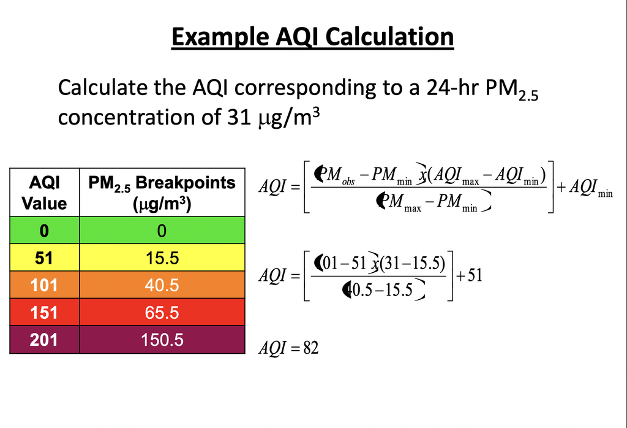

```r
aqi_boston <- clean_names(read_csv("boston-air-quality.csv")) %>%
  mutate(date = ymd(date)) %>%
  mutate(year = as.numeric(year(date))) %>%
  filter(year %in% c(2017, 2018, 2019, 2020, 2021)) %>%
  group_by(year) %>%
  summarize(pm25_mean = mean(pm25, na.rm = T),
           aqi = case_when(pm25_mean <= 15.5 ~ 51,
                         pm25_mean > 15.5 & pm25_mean <= 40.5 ~ 101,
                         pm25_mean > 40.5 & pm25_mean <= 65.5 ~ 151,
                         pm25_mean > 65.5 & pm25_mean <= 150.5 ~ 201,
                         TRUE ~ 251)) %>%
  mutate(neighborhood = "Downtown")

aqi_north_end <- clean_names(read_csv("boston-north end-air-quality.csv")) %>%
  mutate(date = ymd(date)) %>%
  mutate(year = as.numeric(year(date))) %>%
  filter(year %in% c(2017, 2018, 2019, 2020, 2021)) %>%
  group_by(year) %>%
  summarize(pm25_mean = mean(pm25, na.rm = T),
           aqi = case_when(pm25_mean <= 15.5 ~ 51,
                         pm25_mean > 15.5 & pm25_mean <= 40.5 ~ 101,
                         pm25_mean > 40.5 & pm25_mean <= 65.5 ~ 151,
                         pm25_mean > 65.5 & pm25_mean <= 150.5 ~ 201,
                         TRUE ~ 251)) %>%
  mutate(neighborhood = "North End West End")

aqi_roxbury <-  clean_names(read_csv("boston-roxbury-air-quality.csv")) %>%
  mutate(date = ymd(date)) %>%
  mutate(year = as.numeric(year(date))) %>%
  filter(year %in% c(2017, 2018, 2019, 2020, 2021)) %>%
  group_by(year) %>%
  summarize(pm25_mean = mean(pm25, na.rm = T),
           aqi = case_when(pm25_mean <= 15.5 ~ 51,
                         pm25_mean > 15.5 & pm25_mean <= 40.5 ~ 101,
                         pm25_mean > 40.5 & pm25_mean <= 65.5 ~ 151,
                         pm25_mean > 65.5 & pm25_mean <= 150.5 ~ 201,
                         TRUE ~ 251)) %>%
  mutate(neighborhood = "Roxbury")

aqi_dorchester <-  clean_names(read_csv("boston-von hillern-air-quality.csv")) %>%
  mutate(date = ymd(date)) %>%
  mutate(year = as.numeric(year(date))) %>%
  filter(year %in% c(2017, 2018, 2019, 2020, 2021)) %>%
  group_by(year) %>%
  summarize(pm25_mean = mean(pm25, na.rm = T),
           aqi = case_when(pm25_mean <= 15.5 ~ 51,
                         pm25_mean > 15.5 & pm25_mean <= 40.5 ~ 101,
                         pm25_mean > 40.5 & pm25_mean <= 65.5 ~ 151,
                         pm25_mean > 65.5 & pm25_mean <= 150.5 ~ 201,
                         TRUE ~ 251)) %>%
  mutate(neighborhood = "Dorchester")

aqi_all <- aqi_boston %>%
  full_join(aqi_north_end) %>%
  full_join(aqi_roxbury) %>%
  full_join(aqi_dorchester)
```

### Area Deprivation Index (ADI)

**This was another factor we did not use in our final model. One potential reason is that ADI was collinear with neighborhoods. Thus, we did not run the code in the final models but included it below to demonstrate our thought process and work.**

Reading in ADI data from the [Neighborhood Atlas website](https://www.neighborhoodatlas.medicine.wisc.edu/).

*Note:* Codebook as follows:

- TYPE: P indicates post office; U indicates unique zipcode; standard zip codes are left blank
- ZIPID: The 9 digit zip code ID
- FIPS: The block group Census ID
- GISJOIN: Key linkage field to the block group shapefile served by NHGIS
- ADI_NATRANK: National percentile of block group ADI score. PH for suppression due to low population and/or housing, GQ for suppression due to a high group quarters population, and PH-GQ for suppression due to both types of suppression criteria.
- ADI_STATERNK: State-specific decile of block group ADI score. PH for suppression due to low population and/or housing, GQ for suppression due to a high group quarters population, and PH-GQ for suppression due to both types of suppression criteria.

Given that we had ADI data available for 2015 and 2019 only, for analysis purposes, the assumption was made that 2015 is comparable enough to 2017, when our analysis begins; thus 2015 was used as a proxy for 2017.

```r
#Defining a function for mode
getmode <- function(v) {
  uniqv <- unique(v)
   uniqv[which.max(tabulate(match(v, uniqv)))]
}

adi2019 <- clean_names(read.delim('MA_2019_ADI_9 Digit Zip Code_v3.1.txt', sep = ",")) %>%
  mutate(zipid = str_sub(zipid, 2, 6)) %>%
  mutate(neighborhood = "Other") %>%
  mutate(neighborhood = if_else(zipid == "02134", "Allston", neighborhood)) %>%
  mutate(neighborhood = if_else(zipid%in% c("02116", "02199"), "Back Bay", neighborhood)) %>%
  mutate(neighborhood = if_else(zipid == "02108", "Beacon Hill", neighborhood)) %>%
  mutate(neighborhood = if_else(zipid %in% c("02118", "02215"), "Boston", neighborhood)) %>%
  mutate(neighborhood = if_else(zipid == "02135", "Brighton", neighborhood)) %>%
  mutate(neighborhood = if_else(zipid %in% c("02445", "02446", "02447", "02146"), "Brookline", neighborhood)) %>%
  mutate(neighborhood = if_else(zipid %in% c("02138", "02139", "02140", "02141", "02142", "02163", "02238"), "Cambridge", neighborhood)) %>%
  mutate(neighborhood = if_else(zipid == "02129", "Charlestown", neighborhood)) %>%
  mutate(neighborhood = if_else(zipid %in% c("02459", "02467"), "Chestnut Hill", neighborhood)) %>%
  mutate(neighborhood = if_else(zipid == "02111", "Chinatown Leather District", neighborhood)) %>%
  mutate(neighborhood = if_else(zipid %in% c("02122", "02124", "02125"), "Dorchester", neighborhood)) %>%
  mutate(neighborhood = if_else(zipid == c("02101", "02112", "02117", "02123", "02133", "02196", "02201", "02205", "02216"), "Downtown", neighborhood)) %>%
  mutate(neighborhood = if_else(zipid %in% c("02128", "02228"), "East Boston", neighborhood)) %>%
  mutate(neighborhood = if_else(zipid == "02115", "Fenway", neighborhood)) %>%
  mutate(neighborhood = if_else(zipid %in% c("02136", "02137"), "Hyde Park", neighborhood)) %>%
  mutate(neighborhood = if_else(zipid == "02130", "Jamaica Plain", neighborhood)) %>%
  mutate(neighborhood = if_else(zipid == "02126", "Mattapan", neighborhood)) %>%
  mutate(neighborhood = if_else(zipid %in% c("02113", "02114", "02109"), "North End West End", neighborhood)) %>%
  mutate(neighborhood = if_else(zipid == "02131", "Roslindale", neighborhood)) %>%
  mutate(neighborhood = if_else(zipid %in% c("02119", "02120", "02121"), "Roxbury", neighborhood)) %>%
  mutate(neighborhood = if_else(zipid == "02110", "Seaport District", neighborhood)) %>%
  mutate(neighborhood = if_else(zipid %in% c("02143", "02144", "02145"), "Somerville", neighborhood)) %>%
  mutate(neighborhood = if_else(zipid %in% c("02127", "02210"), "South Boston", neighborhood)) %>%
  mutate(neighborhood = if_else(zipid == "02132", "West Roxbury", neighborhood)) %>%
  filter(neighborhood != "Other") %>%
  filter(adi_staternk %in% c("1", "2", "3", "4", "5", "6", "7", "8", "9")) %>%
  mutate(adi_staternk = as.numeric(adi_staternk)) %>% # Removing NAs and converting to numeric
  group_by(neighborhood) %>%
  summarize(adi_mode = getmode(adi_staternk)) %>%
  mutate(year = 2019)


adi2017 <- clean_names(read.delim('MA_2015_ADI_9 Digit Zip Code_v3.1.txt', sep = ",")) %>%
  mutate(zipid = str_sub(zipid, 2, 6)) %>%
  mutate(neighborhood = "Other") %>%
  mutate(neighborhood = if_else(zipid == "02134", "Allston", neighborhood)) %>%
  mutate(neighborhood = if_else(zipid%in% c("02116", "02199"), "Back Bay", neighborhood)) %>%
  mutate(neighborhood = if_else(zipid == "02108", "Beacon Hill", neighborhood)) %>%
  mutate(neighborhood = if_else(zipid %in% c("02118", "02215"), "Boston", neighborhood)) %>%
  mutate(neighborhood = if_else(zipid == "02135", "Brighton", neighborhood)) %>%
  mutate(neighborhood = if_else(zipid %in% c("02445", "02446", "02447", "02146"), "Brookline", neighborhood)) %>%
  mutate(neighborhood = if_else(zipid %in% c("02138", "02139", "02140", "02141", "02142", "02163", "02238"), "Cambridge", neighborhood)) %>%
  mutate(neighborhood = if_else(zipid == "02129", "Charlestown", neighborhood)) %>%
  mutate(neighborhood = if_else(zipid %in% c("02459", "02467"), "Chestnut Hill", neighborhood)) %>%
  mutate(neighborhood = if_else(zipid == "02111", "Chinatown Leather District", neighborhood)) %>%
  mutate(neighborhood = if_else(zipid %in% c("02122", "02124", "02125"), "Dorchester", neighborhood)) %>%
  mutate(neighborhood = if_else(zipid == c("02101", "02112", "02117", "02123", "02133", "02196", "02201", "02205", "02216"), "Downtown", neighborhood)) %>%
  mutate(neighborhood = if_else(zipid %in% c("02128", "02228"), "East Boston", neighborhood)) %>%
  mutate(neighborhood = if_else(zipid == "02115", "Fenway", neighborhood)) %>%
  mutate(neighborhood = if_else(zipid %in% c("02136", "02137"), "Hyde Park", neighborhood)) %>%
  mutate(neighborhood = if_else(zipid == "02130", "Jamaica Plain", neighborhood)) %>%
  mutate(neighborhood = if_else(zipid == "02126", "Mattapan", neighborhood)) %>%
  mutate(neighborhood = if_else(zipid %in% c("02113", "02114", "02109"), "North End West End", neighborhood)) %>%
  mutate(neighborhood = if_else(zipid == "02131", "Roslindale", neighborhood)) %>%
  mutate(neighborhood = if_else(zipid %in% c("02119", "02120", "02121"), "Roxbury", neighborhood)) %>%
  mutate(neighborhood = if_else(zipid == "02110", "Seaport District", neighborhood)) %>%
  mutate(neighborhood = if_else(zipid %in% c("02143", "02144", "02145"), "Somerville", neighborhood)) %>%
  mutate(neighborhood = if_else(zipid %in% c("02127", "02210"), "South Boston", neighborhood)) %>%
  mutate(neighborhood = if_else(zipid == "02132", "West Roxbury", neighborhood)) %>%
  filter(neighborhood != "Other") %>%
  filter(adi_staternk %in% c("1", "2", "3", "4", "5", "6", "7", "8", "9")) %>%
  mutate(adi_staternk = as.numeric(adi_staternk)) %>% # Removing NAs and converting to numeric
  group_by(neighborhood) %>%
  summarize(adi_mode = getmode(adi_staternk)) %>%
  mutate(year = 2017)


adi_all <- full_join(adi2017, adi2019)
```

### Redfin and Boston Magazine data

Read html from Redfin for aggregrate housing sale trends in different Boston neighborhoods. Data from January 2020.

```r
bos <- read_html("https://www.redfin.com/city/1826/MA/Boston/housing-market#recentlysold")
send <- read_html("https://www.redfin.com/neighborhood/2529/MA/Boston/South-End")
dorch <- read_html("https://www.redfin.com/neighborhood/708/MA/Boston/Dorchester/housing-market")
rox <- read_html("https://www.redfin.com/neighborhood/2344/MA/Boston/Roxbury/housing-market")
jp <- read_html("https://www.redfin.com/neighborhood/1381/MA/Boston/Jamaica-Plain/housing-market")
ros <- read_html("https://www.redfin.com/neighborhood/2341/MA/Boston/Roslindale/housing-market")
sbos <- read_html("https://www.redfin.com/neighborhood/2501/MA/Boston/South-Boston/housing-market")
bright <- read_html("https://www.redfin.com/neighborhood/38/MA/Boston/Brighton/housing-market")
nend <- read_html("https://www.redfin.com/neighborhood/186088/MA/Boston/North-End/housing-market")
ctown <- read_html("https://www.redfin.com/neighborhood/455/MA/Boston/Charlestown/housing-market")
bbay <- read_html("https://www.redfin.com/neighborhood/293571/MA/Boston/Back-Bay/housing-market")
hpark <- read_html("https://www.redfin.com/neighborhood/1329/MA/Boston/Hyde-Park/housing-market")
alls <- read_html("https://www.redfin.com/neighborhood/186267/MA/Boston/Allston/housing-market")
ebos <- read_html("https://www.redfin.com/neighborhood/795/MA/Boston/East-Boston/housing-market")
chesthill <- read_html("https://www.redfin.com/neighborhood/186297/MA/Newton/Chestnut-Hill/housing-market")
wrox <- read_html("https://www.redfin.com/neighborhood/3036/MA/Boston/West-Roxbury/housing-market")
beachill <- read_html("https://www.redfin.com/neighborhood/8607/MA/Boston/Beacon-Hill/housing-market")
ken <- read_html("https://www.redfin.com/neighborhood/18856/MA/Boston/Fenway-Kenmore-Square/housing-market")
sea <- read_html("https://www.redfin.com/neighborhood/186286/MA/Boston/Seaport-District/housing-market")
dt <- read_html("https://www.redfin.com/neighborhood/755/MA/Boston/Downtown-Boston/housing-market")
ct <- read_html("https://www.redfin.com/neighborhood/482/MA/Boston/Chinatown-Bay-Village/housing-market")
matta <- read_html("https://www.redfin.com/neighborhood/1640/MA/Boston/Mattapan/housing-market")
#technically not BOS
brook <-read_html("https://www.redfin.com/city/36099/MA/Brookline/housing-market")
camb <-read_html("https://www.redfin.com/city/2833/MA/Cambridge/housing-market")
somer <-read_html("https://www.redfin.com/city/16064/MA/Somerville/housing-market")
```

Scrape data from desired html_node.

```r
t.bos <- bos %>% html_node(".RealEstateTrends") %>% html_text()
t.send <- send %>% html_node(".RealEstateTrends") %>% html_text()
t.dorch <- dorch %>% html_node(".RealEstateTrends") %>% html_text()
t.rox <- rox %>% html_node(".RealEstateTrends") %>% html_text()
t.jp <- jp %>% html_node(".RealEstateTrends") %>% html_text()
t.ros <- ros %>% html_node(".RealEstateTrends") %>% html_text()
t.sbos <- sbos %>% html_node(".RealEstateTrends") %>% html_text()
t.bright <- bright %>% html_node(".RealEstateTrends") %>% html_text()
t.nend <- nend %>% html_node(".RealEstateTrends") %>% html_text()
t.ctown <- ctown %>% html_node(".RealEstateTrends") %>% html_text()
t.bbay <- bbay %>% html_node(".RealEstateTrends") %>% html_text()
t.hpark <- hpark %>% html_node(".RealEstateTrends") %>% html_text()
t.alls <- alls %>% html_node(".RealEstateTrends") %>% html_text()
t.ebos <- ebos %>% html_node(".RealEstateTrends") %>% html_text()
t.chesthill <- chesthill %>% html_node(".RealEstateTrends") %>% html_text()
t.wrox <- wrox %>% html_node(".RealEstateTrends") %>% html_text()
t.beachill <- beachill %>% html_node(".RealEstateTrends") %>% html_text()
t.ken <- ken %>% html_node(".RealEstateTrends") %>% html_text()
t.sea <- sea %>% html_node(".RealEstateTrends") %>% html_text()
t.dt <- dt %>% html_node(".RealEstateTrends") %>% html_text()
t.ct <- ct %>% html_node(".RealEstateTrends") %>% html_text()
t.matta <- matta %>% html_node(".RealEstateTrends") %>% html_text()
#technically not BOS
t.brook <- brook %>% html_node(".RealEstateTrends") %>% html_text()
t.camb <- camb %>% html_node(".RealEstateTrends") %>% html_text()
t.somer <- somer %>% html_node(".RealEstateTrends") %>% html_text()
```

Create function to string proccess scraped data. Final output is datatable.

```r
redfin.fun <- function(x) {
  x %>% str_split_fixed(pattern = "\\%", n=5) %>%
    str_replace_all("[^[:alnum:]]","") %>%
    str_replace_all(c("KSalePrice\\d*"="000",
                    "MSalePrice\\d*"="000000",
                    "sincelastyear"="",
                    "SaleSqFt\\d*"="",
                    "TotalHomesSold"="",
                    "K"="0"))
}

bos.list<-c(t.bos,
t.send,
t.dorch,
t.rox,
t.jp,
t.ros,
t.sbos,
t.bright,
t.nend,
t.ctown,
t.bbay,
t.hpark,
t.alls,
t.ebos,
t.chesthill,
t.wrox,
t.beachill,
t.ken,
t.sea,
t.dt,
t.ct,
t.matta,
t.brook,
t.camb,
t.somer)

rownames<-c("Boston",
"Bay Village South End",
"Dorchester",
"Roxbury",
"Jamaica Plain",
"Roslindale",
"South Boston",
"Brighton",
"North End West End",
"Charlestown",
"Back Bay",
"Hyde Park",
"Allston",
"East Boston",
"Chestnut Hill",
"West Roxbury",
"Beacon Hill",
"Fenway",
"Seaport District",
"Downtown",
"Chinatown Leather District",
"Mattapan",
"Brookline",
"Cambridge",
"Somerville")

funoutput.boston<-lapply(bos.list, redfin.fun)
df.boston <- do.call(rbind, funoutput.boston) %>%
  as_tibble()
colnames(df.boston)<-c("Avg Sale Price", "Price Per SqFt", "Diff from List Price", "Misc", "Number Sold")
df.boston <- cbind(df.boston, rownames) %>%
  dplyr::select(-`Diff from List Price`, -Misc) %>%
  dplyr::rename("Neighborhood"="rownames") %>%
  mutate("Year"=2020) %>%
  mutate_at(c("Avg Sale Price", "Price Per SqFt", "Number Sold"), as.numeric)
head(df.boston)
```

```
##   Avg Sale Price Price Per SqFt Number Sold          Neighborhood Year
## 1       7.50e+05            640         490                Boston 2020
## 2       1.19e+08           1120          45 Bay Village South End 2020
## 3       6.17e+05            422          55            Dorchester 2020
## 4       5.90e+05            309          12               Roxbury 2020
## 5       7.45e+05            544          41         Jamaica Plain 2020
## 6       6.50e+05            481          36            Roslindale 2020
```

```r
col_order <- c("Neighborhood", "Year", "Avg Sale Price", "Price Per SqFt", "Number Sold")
df.boston <- df.boston[, col_order]
df.boston <- df.boston %>% mutate("Type"=NA)
head(df.boston)
```

```
##            Neighborhood Year Avg Sale Price Price Per SqFt Number Sold Type
## 1                Boston 2020       7.50e+05            640         490   NA
## 2 Bay Village South End 2020       1.19e+08           1120          45   NA
## 3            Dorchester 2020       6.17e+05            422          55   NA
## 4               Roxbury 2020       5.90e+05            309          12   NA
## 5         Jamaica Plain 2020       7.45e+05            544          41   NA
## 6            Roslindale 2020       6.50e+05            481          36   NA
```

Historic data scraped from [Boston Magazine](https://www.bostonmagazine.com/best-places-to-live-2017-condos/).

```r
#condo data
condo_sixteen <- read_html("https://www.bostonmagazine.com/best-places-to-live-2017-condos/")
condo_nineteen <- read_html("https://www.bostonmagazine.com/property/top-places-to-live-2019-condos/")
condo_twenty <- read_html("https://www.bostonmagazine.com/property/top-places-to-live-2020-condos/")

#single family housing data
house_sixteen <- read_html("https://www.bostonmagazine.com/best-places-to-live-2017-single-family-homes/")
house_nineteen <- read_html("https://www.bostonmagazine.com/top-places-to-live-2019-single-family-homes/")
house_twenty <- read_html("https://www.bostonmagazine.com/property/single-family-home-prices/")
```

Identify correct table in html code. **OF NOTE, these are median prices for each neighborhood.** Historic 2015 and 2016 data.

```r
#2015 and 2016 Condo data
#scrape and clean table data
t_condo_sixteen <- condo_sixteen %>% html_nodes("table") %>% html_table() %>% .[[1]] %>%
  dplyr::select(-contains(c("Change", "Days on Market", "2006", "2011"))) %>%
  mutate_all(funs(gsub("[[:punct:]]", "", .))) %>%
  filter(str_detect(`Neighborhood / Town`, 'Boston|Brookline|Cambridge|Somerville')) %>%
  mutate_at(c(2:5), as.numeric) %>%
  as_tibble()
col_order2 <-c("Neighborhood / Town", "2016 Median Price", "2016 Number of Sales", "2015 Median Price", "2015 Number of Sales")
t_condo_sixteen <- t_condo_sixteen[, col_order2]
head(t_condo_sixteen)
```

```
## # A tibble: 6 × 5
##   `Neighborhood / Town`  `2016 Median Pric… `2016 Number of S… `2015 Median Pri…
##   <chr>                               <dbl>              <dbl>             <dbl>
## 1 Boston  Citywide                   574900               4309            529000
## 2 Boston  Allston                    429000                 69            377900
## 3 Boston  Back Bay                  1050000                384           1181250
## 4 Boston  Bay Village  …             600000                  6            800000
## 5 Boston  Beacon Hill                720000                128            660000
## 6 Boston  Brighton                   408750                196            375000
## # … with 1 more variable: 2015 Number of Sales <dbl>
```

```r
#convert data to long format
l_condo_sixteen <- t_condo_sixteen %>% gather(key = "Year" , value = "Value", -"Neighborhood / Town") %>%
  separate(Year, c("Year", "Value Type"), extra = "merge") %>%
  spread("Value Type", "Value") %>%
  mutate_at("Year", as.numeric) %>%
  arrange(Year) %>%
  mutate("Type"="Condo", "Price Per SqFt"=NA)
colnames(l_condo_sixteen)<-c("Neighborhood", "Year", "Avg Sale Price", "Number Sold", "Type", "Price Per SqFt")
l_condo_sixteen <-l_condo_sixteen[, c("Neighborhood", "Year", "Avg Sale Price", "Price Per SqFt", "Number Sold", "Type")]
rename_hood <-str_replace_all(l_condo_sixteen$Neighborhood, c("Boston  "="", "  "=" "))
rename_hood
```

```
##  [1] "Allston"                    "Back Bay"
##  [3] "Bay Village South End"      "Beacon Hill"
##  [5] "Brighton"                   "Charlestown"
##  [7] "Chinatown Leather District" "Citywide"
##  [9] "Dorchester"                 "East Boston"
## [11] "Fenway"                     "Hyde Park"
## [13] "Jamaica Plain"              "Mattapan"
## [15] "North End West End"         "Roslindale"
## [17] "Roxbury"                    "South Boston"
## [19] "West Roxbury"               "Brookline"
## [21] "Cambridge"                  "Somerville"
## [23] "Allston"                    "Back Bay"
## [25] "Bay Village South End"      "Beacon Hill"
## [27] "Brighton"                   "Charlestown"
## [29] "Chinatown Leather District" "Citywide"
## [31] "Dorchester"                 "East Boston"
## [33] "Fenway"                     "Hyde Park"
## [35] "Jamaica Plain"              "Mattapan"
## [37] "North End West End"         "Roslindale"
## [39] "Roxbury"                    "South Boston"
## [41] "West Roxbury"               "Brookline"
## [43] "Cambridge"                  "Somerville"
```

```r
l_condo_sixteen <- l_condo_sixteen %>% mutate(Neighborhood=rename_hood)
head(l_condo_sixteen)
```

```
## # A tibble: 6 × 6
##   Neighborhood        Year `Avg Sale Price` `Price Per SqFt` `Number Sold` Type
##   <chr>              <dbl>            <dbl> <lgl>                    <dbl> <chr>
## 1 Allston             2015           377900 NA                          87 Condo
## 2 Back Bay            2015          1181250 NA                         378 Condo
## 3 Bay Village South…  2015           800000 NA                         555 Condo
## 4 Beacon Hill         2015           660000 NA                         148 Condo
## 5 Brighton            2015           375000 NA                         226 Condo
## 6 Charlestown         2015           590000 NA                         242 Condo
```

```r
#2015 and 2016 single family house data
#scrape and clean table data
t_house_sixteen <- house_sixteen %>% html_nodes("table") %>% html_table() %>% .[[1]] %>%
  dplyr::select(-contains(c("Change", "Days on Market", "2006", "2011"))) %>%
  mutate_all(funs(gsub("[[:punct:]]", "", .))) %>%
  filter(str_detect(`Neighborhood / Town`, 'Boston|Brookline|Cambridge|Somerville')) %>%
  mutate_at(c(2:5), as.numeric) %>%
  as_tibble()
col_order2 <-c("Neighborhood / Town", "2016 Median Price", "2016 No. of Sales", "2015 Median Price", "2015 No. of Sales")
t_house_sixteen <- t_house_sixteen[, col_order2]
head(t_house_sixteen)
```

```
## # A tibble: 6 × 5
##   `Neighborhood / Town`   `2016 Median Pric… `2016 No. of Sal… `2015 Median Pri…
##   <chr>                                <dbl>             <dbl>             <dbl>
## 1 Boston  Citywide                    530000              1026            475000
## 2 Boston  Allston                     745000                 3            773000
## 3 Boston  Back Bay                   4285000                 6           6350000
## 4 Boston  Bay Village  S…            1144000                 1           2525000
## 5 Boston  Beacon Hill                3050000                17                NA
## 6 Boston  Brighton                    687500                26            582500
## # … with 1 more variable: 2015 No. of Sales <dbl>
```

```r
#convert data to long format
l_house_sixteen <- t_house_sixteen %>% gather(key = "Year" , value = "Value", -"Neighborhood / Town") %>%
  separate(Year, c("Year", "Value Type"), extra = "merge") %>%
  spread("Value Type", "Value") %>%
  mutate_at("Year", as.numeric) %>%
  arrange(Year) %>%
  mutate("Type" = "House", "Price Per SqFt"=NA)
colnames(l_house_sixteen)<-c("Neighborhood", "Year", "Avg Sale Price", "Number Sold", "Type", "Price Per SqFt")
l_house_sixteen <-l_house_sixteen[, c("Neighborhood", "Year", "Avg Sale Price", "Price Per SqFt", "Number Sold", "Type")]
rename_hood2 <-str_replace_all(l_house_sixteen$Neighborhood, c("Boston  "="", "  "=" "))
rename_hood2
```

```
##  [1] "Allston"                    "Back Bay"
##  [3] "Bay Village South End"      "Beacon Hill"
##  [5] "Brighton"                   "Charlestown"
##  [7] "Chinatown Leather District" "Citywide"
##  [9] "Dorchester"                 "East Boston"
## [11] "Fenway"                     "Hyde Park"
## [13] "Jamaica Plain"              "Mattapan"
## [15] "North End West End"         "Roslindale"
## [17] "Roxbury"                    "South Boston"
## [19] "West Roxbury"               "Brookline"
## [21] "Cambridge"                  "Somerville"
## [23] "Allston"                    "Back Bay"
## [25] "Bay Village South End"      "Beacon Hill"
## [27] "Brighton"                   "Charlestown"
## [29] "Chinatown Leather District" "Citywide"
## [31] "Dorchester"                 "East Boston"
## [33] "Fenway"                     "Hyde Park"
## [35] "Jamaica Plain"              "Mattapan"
## [37] "North End West End"         "Roslindale"
## [39] "Roxbury"                    "South Boston"
## [41] "West Roxbury"               "Brookline"
## [43] "Cambridge"                  "Somerville"
```

```r
l_house_sixteen <- l_house_sixteen %>% mutate(Neighborhood=rename_hood2)
head(l_house_sixteen)
```

```
## # A tibble: 6 × 6
##   Neighborhood        Year `Avg Sale Price` `Price Per SqFt` `Number Sold` Type
##   <chr>              <dbl>            <dbl> <lgl>                    <dbl> <chr>
## 1 Allston             2015           773000 NA                           1 House
## 2 Back Bay            2015          6350000 NA                           9 House
## 3 Bay Village South…  2015          2525000 NA                          27 House
## 4 Beacon Hill         2015               NA NA                          NA House
## 5 Brighton            2015           582500 NA                          28 House
## 6 Charlestown         2015           895000 NA                          61 House
```

Historic 2017 data. **NO No. Units Sold Data**

```r
#2017 and 2018 Condo data
#scrape and clean table data
t_condo_nineteen <- condo_nineteen %>% html_nodes("table") %>% html_table() %>% .[[1]] %>%
  dplyr::select(-contains(c("Change", "Days on Market", "2013", "2008", "2018"))) %>%
  mutate_all(funs(gsub("[[:punct:]]", "", .))) %>%
  mutate_at(c(2:ncol(.)), as.numeric) %>%
  as_tibble()
head(t_condo_nineteen)
```

```
## # A tibble: 6 × 2
##   `Boston Neighborhoods` `2017 Median Price`
##   <chr>                                <dbl>
## 1 Allston                             480000
## 2 Back Bay                           1100000
## 3 Bay VillageSouth End                615000
## 4 Beacon Hill                         952500
## 5 Brighton                            430000
## 6 Charlestown                         690000
```

```r
#convert data to long format
l_condo_nineteen <- t_condo_nineteen %>% gather(key = "Year" , value = "Value", -"Boston Neighborhoods") %>%
  separate(Year, c("Year", "Value Type"), extra = "merge") %>%
  spread("Value Type", "Value") %>%
  mutate_at("Year", as.numeric) %>%
  arrange(Year) %>%
  mutate("Price Per SqFt"=NA, "Number Sold"=NA, "Type"="Condo")
colnames(l_condo_nineteen)<-c("Neighborhood", "Year", "Avg Sale Price", "Price Per SqFt", "Number Sold", "Type")
rename_hood3 <-str_replace_all(l_condo_nineteen$Neighborhood, c("Bay VillageSouth End"="Bay Village South End",
                                                              "ChinatownLeather Dist"="Chinatown Leather District",
                                                              "North EndWest End"="North End West End"))
l_condo_nineteen <- l_condo_nineteen %>% mutate(Neighborhood=rename_hood3)
head(l_condo_nineteen)
```

```
## # A tibble: 6 × 6
##   Neighborhood        Year `Avg Sale Price` `Price Per SqFt` `Number Sold` Type
##   <chr>              <dbl>            <dbl> <lgl>            <lgl>         <chr>
## 1 Allston             2017           480000 NA               NA            Condo
## 2 Back Bay            2017          1100000 NA               NA            Condo
## 3 Bay Village South…  2017           615000 NA               NA            Condo
## 4 Beacon Hill         2017           952500 NA               NA            Condo
## 5 Brighton            2017           430000 NA               NA            Condo
## 6 Charlestown         2017           690000 NA               NA            Condo
```

```r
#2017 and 2018 single family house data
#scrape and clean table data
t_house_nineteen <- house_nineteen %>% html_nodes("table") %>% html_table() %>% .[[1]] %>%
  dplyr::select(-contains(c("Change", "Days on Market", "2013", "2008", "2018"))) %>%
  mutate_all(funs(gsub("[[:punct:]]", "", .))) %>%
  filter(str_detect(`City/Town`, 'Boston|Brookline|Cambridge|Somerville')) %>%
  mutate_at(c(2:ncol(.)), as.numeric) %>%
  as_tibble()
head(t_house_nineteen)
```

```
## # A tibble: 4 × 2
##   `City/Town` `2017 Median Price`
##   <chr>                     <dbl>
## 1 Boston                   580000
## 2 Brookline               1912500
## 3 Cambridge               1455000
## 4 Somerville               733750
```

```r
#convert data to long format
l_house_nineteen <- t_house_nineteen %>% gather(key = "Year" , value = "Value", -"City/Town") %>%
  separate(Year, c("Year", "Value Type"), extra = "merge") %>%
  spread("Value Type", "Value") %>%
  mutate_at("Year", as.numeric) %>%
  arrange(Year)%>%
  mutate("Price Per SqFt"=NA, "Number Sold"=NA, "Type"="House")
colnames(l_house_nineteen)<-c("Neighborhood", "Year", "Avg Sale Price", "Price Per SqFt", "Number Sold", "Type")
head(l_house_nineteen)
```

```
## # A tibble: 4 × 6
##   Neighborhood  Year `Avg Sale Price` `Price Per SqFt` `Number Sold` Type
##   <chr>        <dbl>            <dbl> <lgl>            <lgl>         <chr>
## 1 Boston        2017           580000 NA               NA            House
## 2 Brookline     2017          1912500 NA               NA            House
## 3 Cambridge     2017          1455000 NA               NA            House
## 4 Somerville    2017           733750 NA               NA            House
```

Historic 2018 and 2019 data.

```r
#2018 and 2019 Condo data
#scrape and clean table data
t_condo_twenty <- condo_twenty %>% html_nodes("table") %>% html_table() %>% .[[1]] %>%
  dplyr::select(-contains(c("Change", "DOM", "2009", "2014"))) %>%
  mutate_all(funs(gsub("[[:punct:]]", "", .))) %>%
  mutate_at(c(2:ncol(.)), as.numeric) %>%
  as_tibble()
t_condo_twenty <- t_condo_twenty[, c("Neighborhood", "2019 Median Price", "2019 Number of Sales", "2018 Median Price", "2018 Number of Sales")]
head(t_condo_twenty)
```

```
## # A tibble: 6 × 5
##   Neighborhood         `2019 Median Price` `2019 Number of Sa… `2018 Median Pri…
##   <chr>                              <dbl>               <dbl>             <dbl>
## 1 Allston                           501811                  45            645000
## 2 Back Bay                         1824379                 321           1200000
## 3 Bay VillageSouth End             1293000                   8            972000
## 4 Beacon Hill                      1630124                 154            790000
## 5 Brighton                          538327                 175            517500
## 6 Charlestown                       764325                 215            727750
## # … with 1 more variable: 2018 Number of Sales <dbl>
```